# 326.212 Homework 1

#### Problem 6. When using facet_grid() you should usually put the variable with more unique levels in the columns. Why?

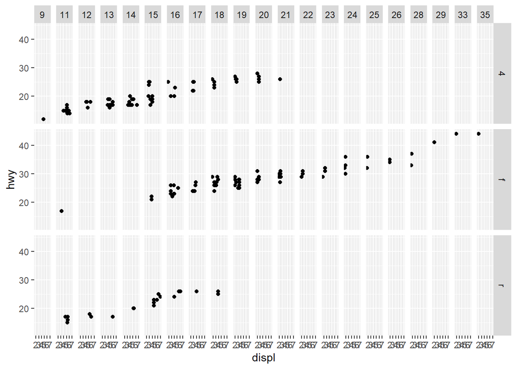

```r
ggplot(data = mpg) + geom_point(mapping = aes(x = displ, y = hwy)) + facet_grid(drv ~ cty)
```

cty가 facet_grid의 column일때

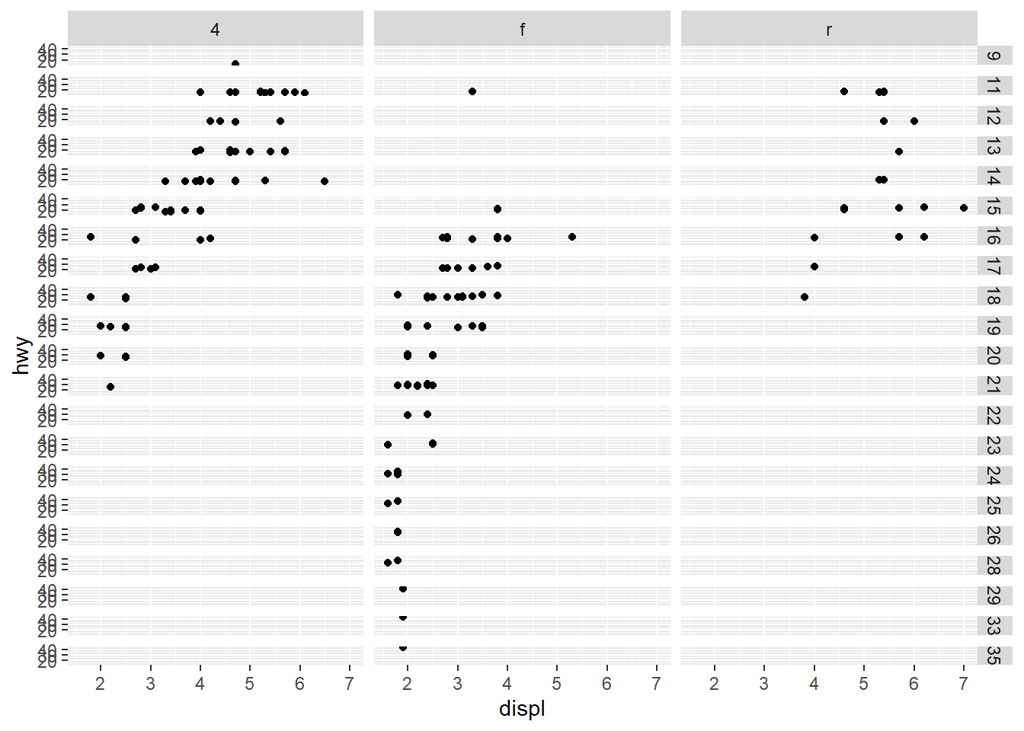

```r
ggplot(data = mpg) + geom_point(mapping = aes(x = displ, y = hwy)) + facet_grid(cty ~ drv)
```

drv가 facet_grid의 column일떄

위와 같이 두가지 방법으로 facet_grid를 이용하여 facet을 사용한 그래프를 그렸을때, drv보다 cty에 더 다양한 종류의 데이터가 존재함을 알 수 있다.

왜 column부분에 더 많은 종류의 데이터가 존재하는 변수를 넣어야하냐면, plot을 그릴때 세로방향은 상대적으로 확장이 용이한 반면, 가로방향의 경우는 확장이 힘드므로 column에 더 많은 종류의 데이터가 존재하는 변수가 들어가도록 하여 그래프를 더 보기좋게 만들수 있다.

### Textbook 3.6.1

#### Problem 2. Run this code in your head and predict what the output will look like. Then, run the code in R and check your predictions.

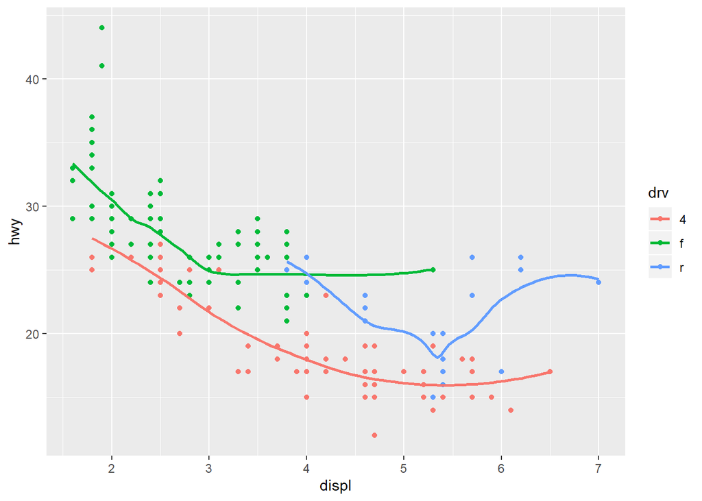

```r
ggplot(data = mpg, mapping = aes(x = displ, y = hwy, color = drv)) +
  geom_point() +
  geom_smooth(se = FALSE)
```

실제 코드가 실행되었을때 출력되는 그래프도 예측처럼 나왔음을 알 수 있다.

#### Problem 6. Recreate the R code necessary to generate the following graphs.

##### #1.

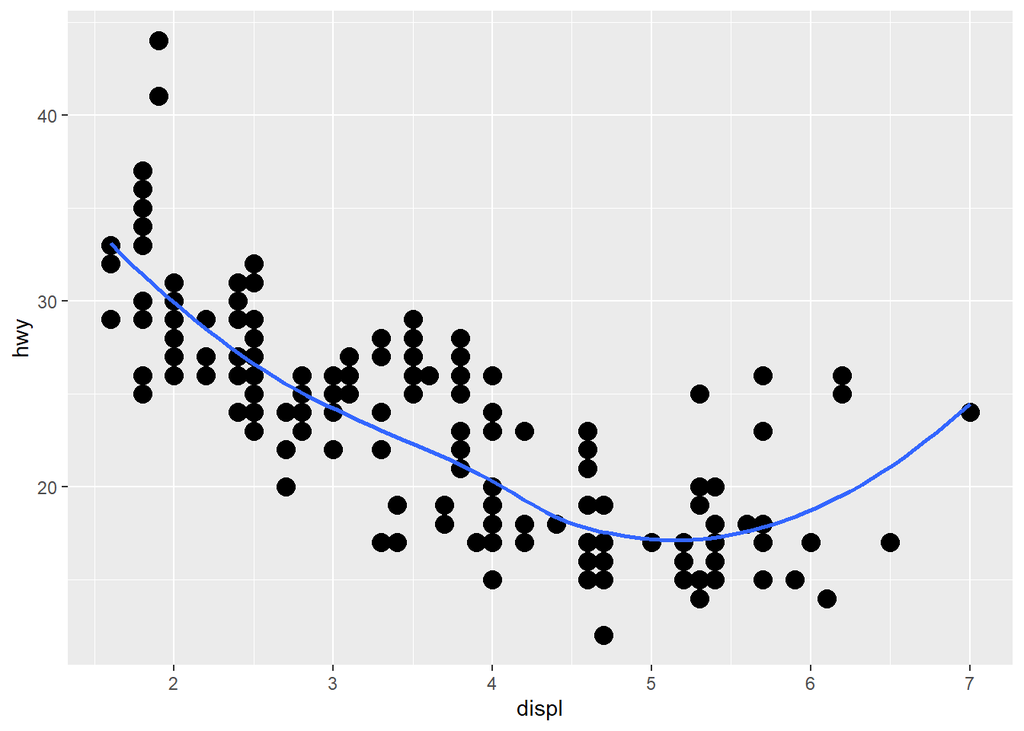

```r
ggplot(data = mpg, mapping = aes(x = displ, y = hwy)) + geom_point(size = 4) + geom_smooth(se = FALSE)
```

##### #2.

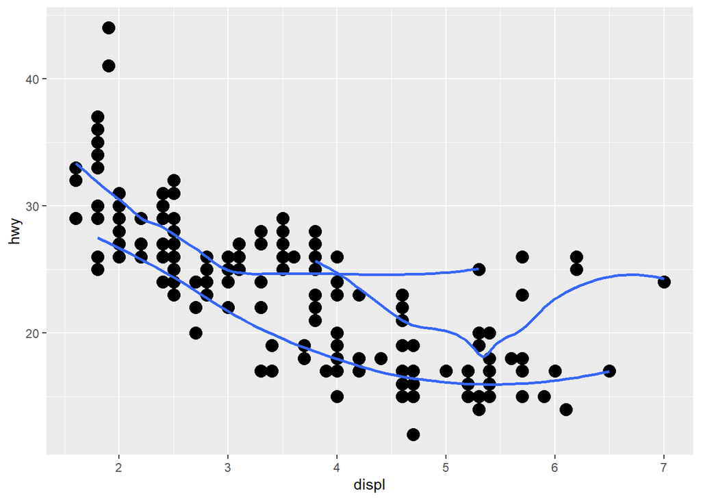

```r
ggplot(data = mpg, mapping = aes(x = displ, y = hwy)) + geom_point(size = 4) + geom_smooth(mapping = aes(group = drv), se = FALSE)
```

##### #3.

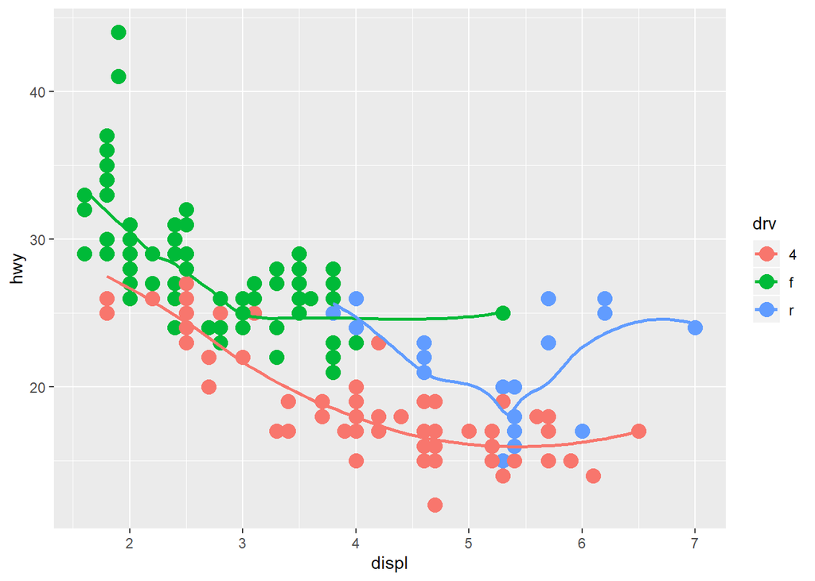

```r
ggplot(data = mpg, mapping = aes(x = displ, y = hwy, color = drv)) + geom_point(size = 4) + geom_smooth(se = FALSE)
```

##### #4.

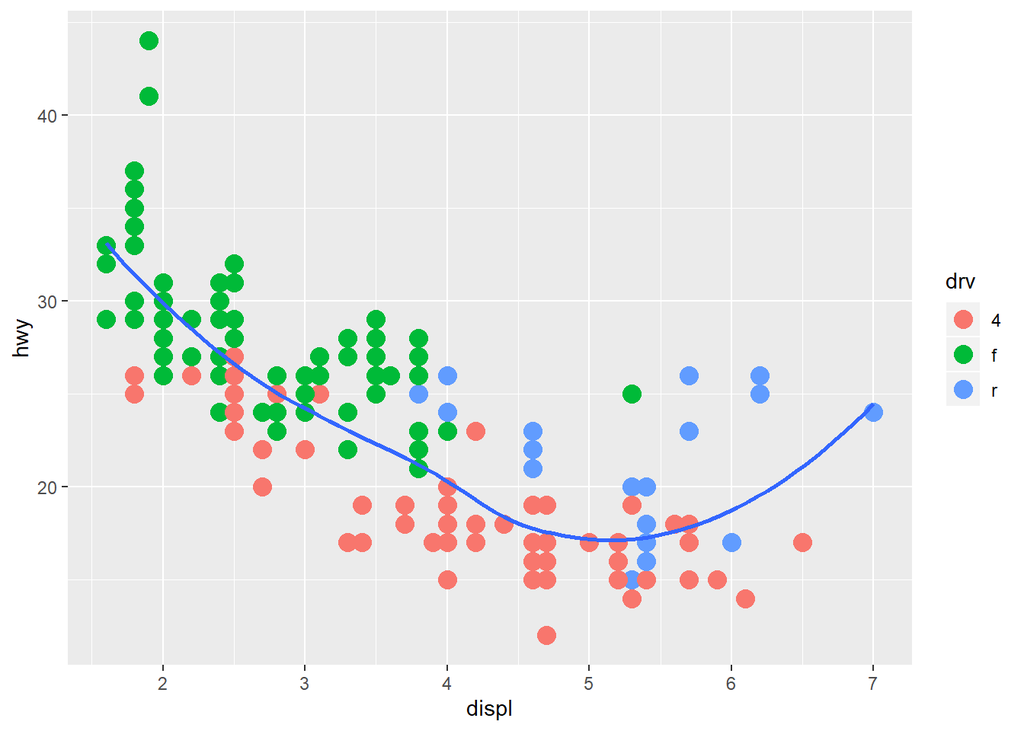

```r
ggplot(data = mpg, mapping = aes(x = displ, y = hwy)) + geom_point(mapping = aes(color = drv), size = 4) + geom_smooth(se = FALSE)
```

##### #5.

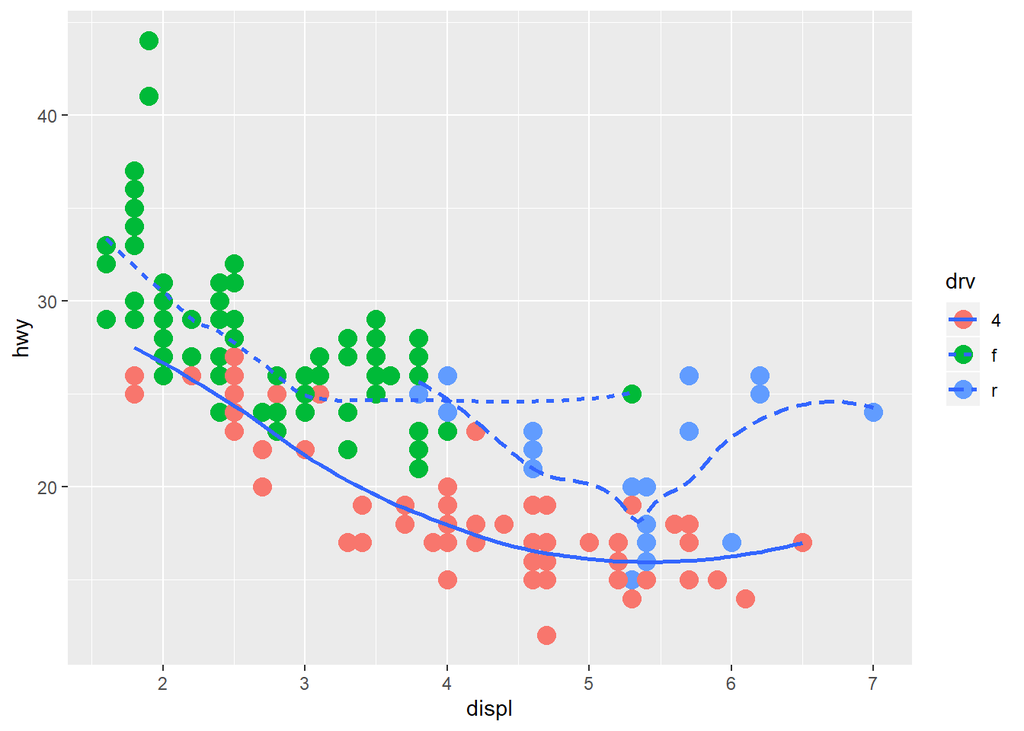

```r
ggplot(data = mpg, mapping = aes(x = displ, y = hwy)) + geom_point(mapping = aes(color = drv), size = 4) + geom_smooth(mapping = aes(linetype = drv), se = FALSE)
```